# Single-cell RNA sequencing ~ Session 1

Rockefeller University, Bioinformatics Resource Centre

http://rockefelleruniversity.github.io/scRNA-seq/

## Overview

In this course we are going to introduce basic analysis for single-cell RNAseq, with a specific focus on the *10X system*. The course is divided into three sessions. In the first session, we will introduce how to interpret the **Cell Ranger QC report** and how to do analysis with the **LOUPE Browser**. We will also demonstrate the customized analysis we can support right know. In the Second session, we will demonstrate how to process scRNAseq data and make QC reports with **Seurat**. In the third session, we will discuss how to to do more advanced analysis and QC with **Bioconductor** packages.

# Cell Ranger results

## Cell Ranger

[Cell Ranger](https://support.10xgenomics.com/single-cell-gene-expression/software/pipelines/latest/what-is-cell-ranger) is a widely used software for single-cell sequencing data analysis. It supports various kinds of analysis for *10X single-cell sequencing data*. - Alignment and counting - Analysis of VDJ changes - Datasets aggregation - Convert BCL files (raw files) into FASTQ files - Generation of customized GTF and Genome files

## Basic reports of Cell Ranger

- QC Report
- cloupe file: can be processed by [LOUPE Browser](https://support.10xgenomics.com/single-cell-gene-expression/software/visualization/latest/what-is-loupe-cell-browser)

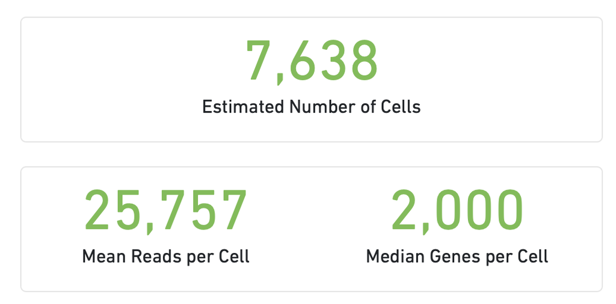

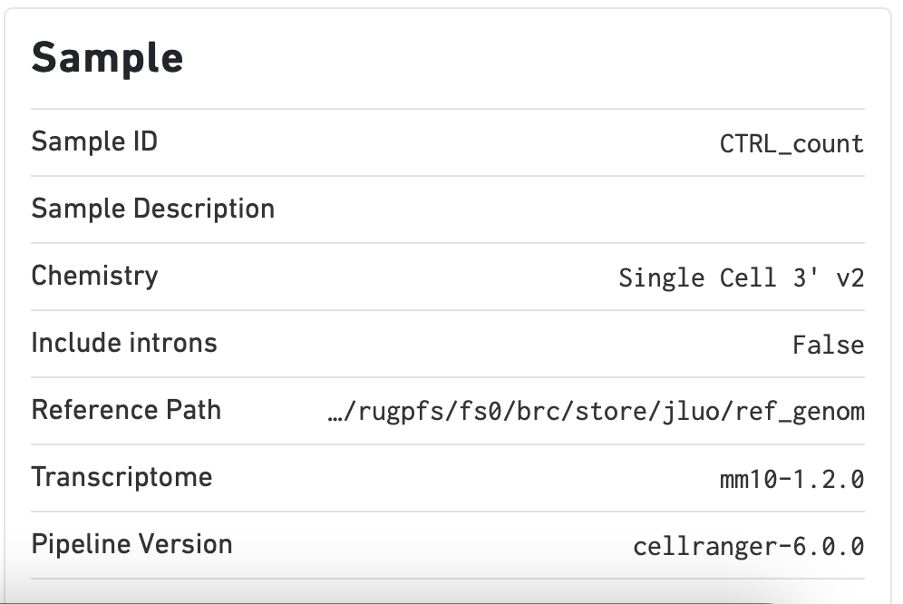

## Sequencing QC

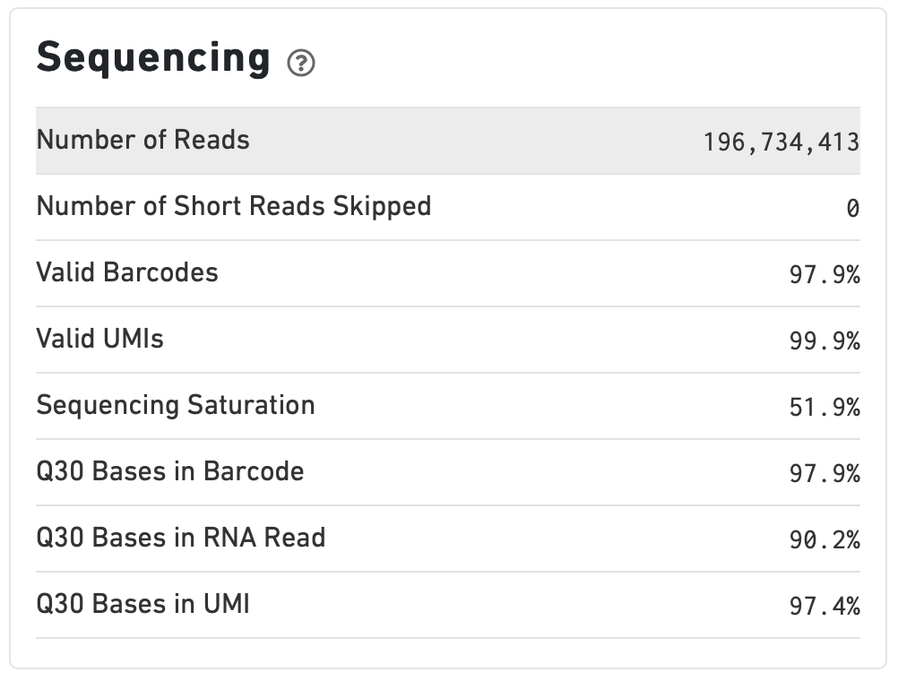

## Mapping QC

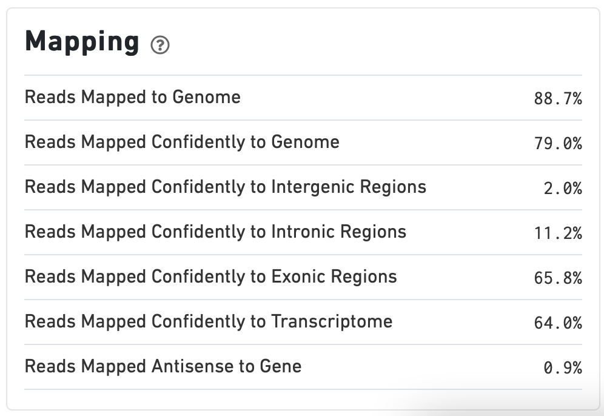

## General information

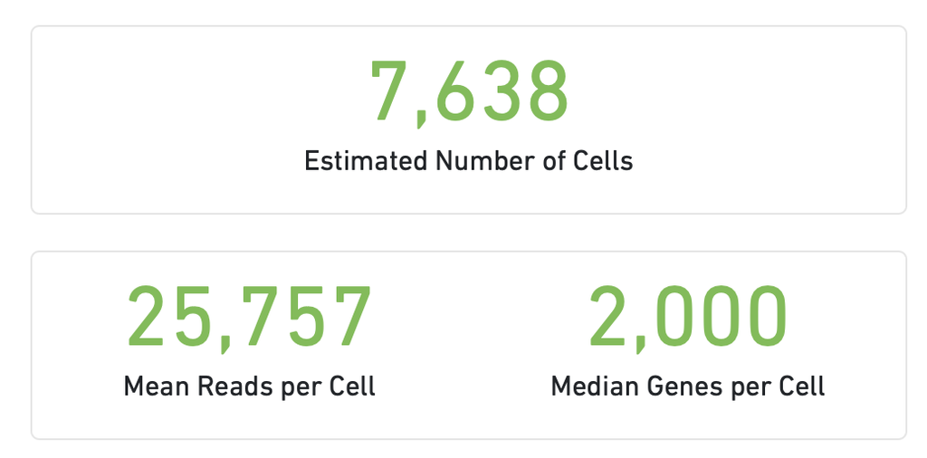

- How many cells should we get?
- Is the throughput enough?

*It depends on the sample characteristics and library complexities*

## How to determin cell numbers?

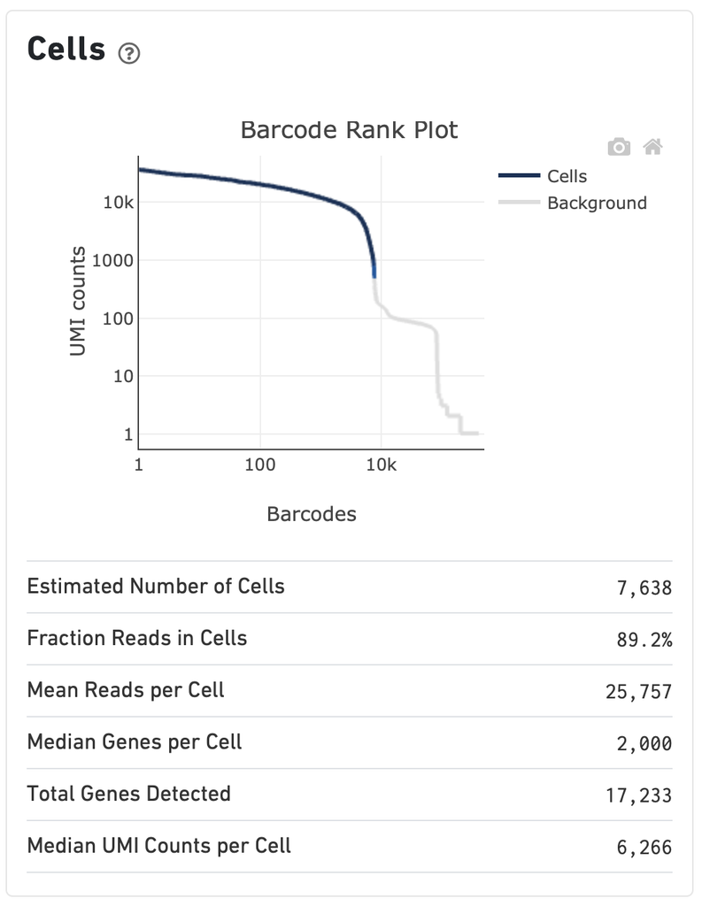

## Knee plot

- [Knee plot](https://liorpachter.wordpress.com/tag/knee-plot/) is applied to determine real cell numbers in a single-cell cohort.
- The x-axis represented the barcodes **ranked by UMI counts** inside the cell barcodes. Y-axis represents the UMI counts detected per cell barcode.
- A knee plot usually contains two bumps. We would take the **mid-point** of the first bump as a cut-off to differentiate real cells and backgrounds (empty droplets).
- As we defined the real cells and empty droplets, we could estimate the transcripts detected in real cell or empty droplets.
- The transcripts in empty droplet, so call **ambient RNA**, are cell-free RNAs falsely included in droplets. We will demonstrate how to remove interference of ambient RNAs in session 3.

## How to determine throughput?

- Downsampling and evaluate median gene per cells in different throughput (Mean reads per cell)
- Downsampling and evaluate proportion of unique UMIs in different throughput (Mean reads per cell)

## genes vs throughput

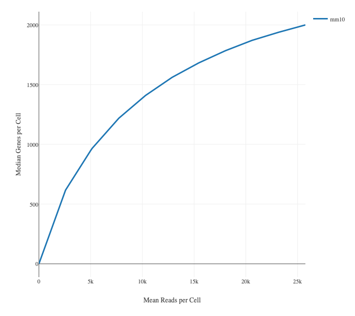

*Seems not saturated yet*

## Saturation vs throughput

- Saturation: uniquely detected UMIs in total UMI
- Can evaluate both saturation and library complexity, like PCR duplication

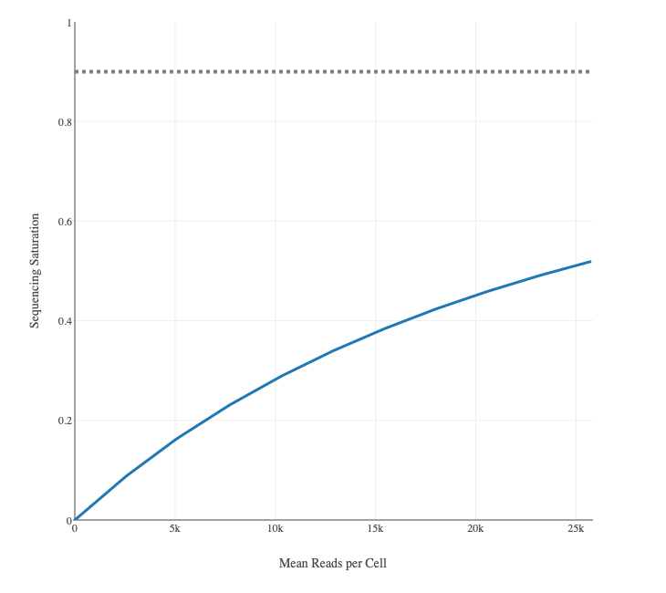

*Seems still not saturated and with lower library complexity, probably higher PCR duplicates.*

## tSNE plot and clustering

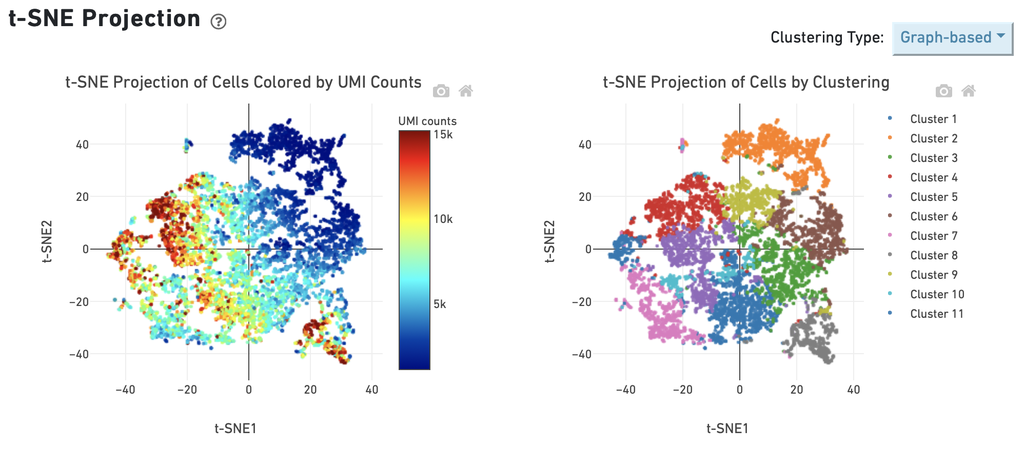

*Seems the cells were grouped by UMI counts.*

## Data visualization with LOUPE Browser

- Please install the latest version
- How to access the expression of particular genes
- How to use split view
- How to define sub-groups
- How to calculate differential gene expression
- Could I import projections and more information generated by external programs?

# Customized Analysis

## Demonstration

Here we use an article published by Fuchs Lab as an example to demonstrate the customized analysis we have done here at the BRC. Please access this [article](https://elifesciences.org/articles/56980). - General QC plots - Data integration and normalization - Clustering - Annotate cell types - Pseudotime analysis - Differential gene expression and single-cell pathway analysis

## The next two sessions

We will also use the data of the eLife paper in next two sessions. You can download the data from GEO [link](https://www.ncbi.nlm.nih.gov/geo/query/acc.cgi?acc=GSE147415) or from DropBox [link](https://www.dropbox.com/sh/ztu0pucvu21szxm/AABGUhTryKp1T1CsoEUFRPcwa?dl=0).